# Reproducible Research: Peer Assessment 1

The data for this assignment consists of activity measurements:

- *steps*: Number of steps taking in a 5-minute interval (missing values are coded as NA).
- *date*: The date on which the measurement was taken in YYYY-MM-DD format.
- *interval*: Identifier for the 5-minute interval in which measurement was taken.

It is contained in the activity.zip file in this repo.

This knitr document has been run with the following global commands:

- No scientific notation for long numbers.
- No digits after the point for floating point numbers.

```r
options(scipen = 1, digits = 0)
```

## Loading and preprocessing the data

First, all library includes are listed. This way, it is immediately signalled if all necessary packages are installed or not.

```r
library(plyr)
library(lattice)
```

Then, the activity data is unzipped and read it into a data frame.

```r
unzip("activity.zip")
activity <- read.csv("activity.csv")
activity$date <- as.POSIXct(activity$date)
```

## What is mean total number of steps taken per day?

The step amounts in the activity data are aggregated by day.

```r
activity_by_day <- ddply(activity, .(date), summarize, steps = sum(steps, na.rm = TRUE))
```

The figure below shows the histogram of steps taken by day.

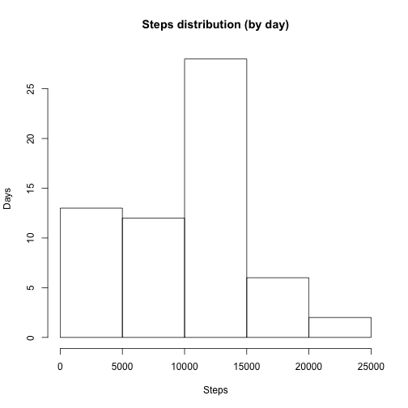

```r
hist(activity_by_day$steps, xlab = "Steps", ylab = "Days", main = "Steps distribution (by day)")
```

```r
mean <- mean(activity_by_day$steps)
median <- median(activity_by_day$steps)
```

On average, 9354 steps were taken by day, with a median of 10395 steps.

## What is the average daily activity pattern?

The step amounts are aggregated by (5-minute) interval and averaged over all days.

```r
activity_by_interval <- ddply(activity, .(interval), summarize, avg_steps = mean(steps,
    na.rm = TRUE))
```

The figure below shows a time series of average daily step pattern in 5-minute intervals.

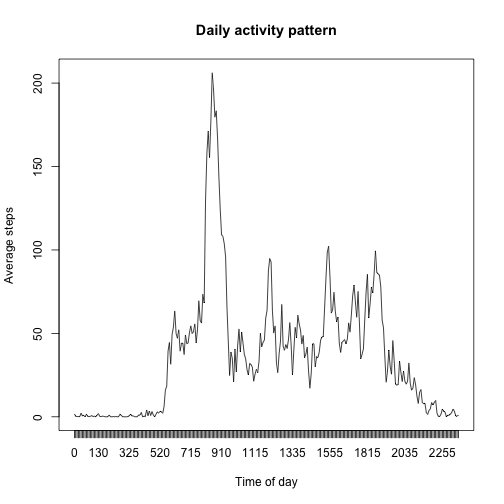

```r
plot(activity_by_interval$avg_steps, type = "l", xaxt = "n", xlab = "Time of day",
    ylab = "Average steps", main = "Daily activity pattern")
axis(1, at = 1:length(activity_by_interval$interval), labels = activity_by_interval$interval)
```

```r
max_steps_in_day <- activity_by_interval[which.max(activity_by_interval$avg_steps),
    ]
```

The most steps in a single 5-minute interval on average were at 835.

## Imputing missing values

```r
valid <- complete.cases(activity$steps)
nr_of_NAs <- sum(!valid)
```

The activity data set contains 2304 rows with NA values.

Missing values are imputed by taking the daily average steps for that interval over the entire dataset.

```r
imputed_activity <- activity
for (i in 1:length(imputed_activity$steps)) {
    if (is.na(imputed_activity$steps[i])) {
        interval <- imputed_activity$interval[i]
        index <- activity_by_interval$interval == interval
        imputed_activity$steps[i] <- activity_by_interval$avg_steps[index]
    }
}
```

The step amounts of the new imputed activity data are again aggregated by day.

```r
imputed_activity_by_day <- ddply(imputed_activity, .(date), summarize, steps = sum(steps,
    na.rm = TRUE))
```

The histogram below shows steps taken by day of the imputed activity data.

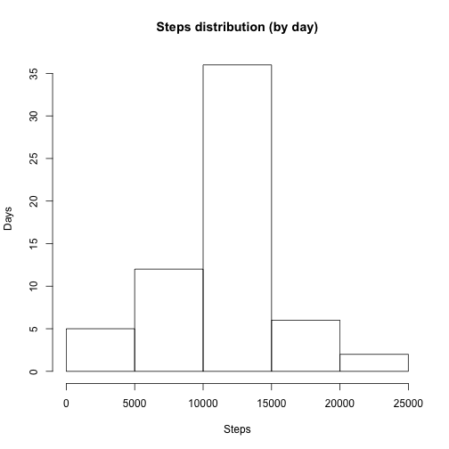

```r
hist(imputed_activity_by_day$steps, xlab = "Steps", ylab = "Days", main = "Steps distribution (by day)")
```

```r
imputed_mean <- mean(imputed_activity_by_day$steps)
imputed_median <- median(imputed_activity_by_day$steps)
```

The average by day of the imputed data is 10766 steps, with a median of 10766 steps.

These values differ from the base activity data. The choice of imputing by mean steps over all days by 5-minute interval combined with the fact that, when missing values (NAs) are present, they are present for a full day has resulted in the same mean and median for the imputed activity dataset. They are also higher than in the base activity data set.

## Are there differences in activity patterns between weekdays and weekends?

A new factor variable is introduced to distinguish between weekdays and weekends.

```r
imputed_activity$time_of_week <- as.factor(ifelse(weekdays(imputed_activity$date) %in%
    c("Saturday", "Sunday"), "weekend", "weekday"))
```

From this, a panel plot containing a time series chart for both weekdays and weekends is created, showing the average over all days by 5-minute interval.

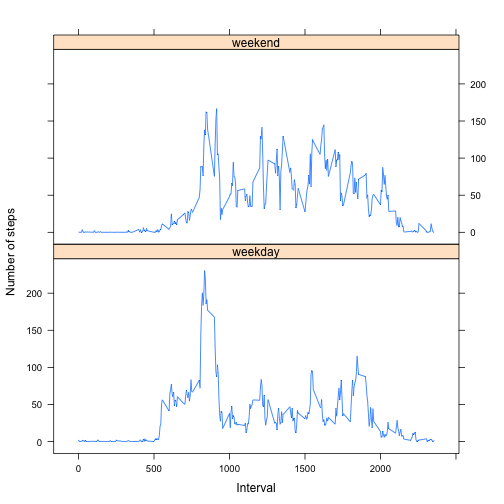

```r
temp_a <- ddply(imputed_activity[imputed_activity$time_of_week == "weekday",
    ], .(interval), summarize, avg_steps = mean(steps, na.rm = TRUE), time_of_week = as.factor("weekday"))
temp_b <- ddply(imputed_activity[imputed_activity$time_of_week == "weekend",
    ], .(interval), summarize, avg_steps = mean(steps, na.rm = TRUE), time_of_week = as.factor("weekend"))

imputed_activity_by_interval <- rbind(temp_a, temp_b)

xyplot(avg_steps ~ interval | time_of_week, data = imputed_activity_by_interval,
    type = "l", layout = c(1, 2), xlab = "Interval", ylab = "Number of steps")
```